# Klassification

Kate

11 декабря 2018 г

# Внимание!

# Внимание!

# Внимание!

# Биномиальная классификация ниже! Она есть!

## А пока, строим просто деревья

### Загрузим наши данные: (Беру данные по наркоманам, посмотрю как классифицируется. например, разобъет по месту лечения: амбулаторно и диспансер. Итак)

```r
Data <- read.csv("D:/Учеба/1 КУРС МАГИСТРАТУРА/Алексеева/DATA/DataNark.csv", header = TRUE, sep = ";",dec = ",")
head(Data)
```

```
##   prcod intpla sex age educat curwor asi1_med asi2_emp asi3_alc asi4_dr
## 1     4      1   0  18      1      1     0.19      0.7     0.12     0.3
## 2     2      2   1  30      4      1     0.44      0.2     0.01     0.3
## 3     2      1   0  23      2      0     0.50      1.0     0.30     0.3
## 4     4      1   0  20      2      1     0.00      0.8     0.05     0.3
## 5     3      2   0  20      2      0     0.00      0.8     0.78     0.2
## 6     1      1   0  24      2      0     0.52      0.5     0.10     0.3
##   asi5_leg asi6_soc asi7_psy asid3_dyr tlfba2   tlfbh2 st ha se cravin
## 1     0.06      0.5      0.2         3    8.9    231,7  0  1  0    4.6
## 2     0.00      0.6      0.0         1    0.3    727,8  0  0  0    9.7
## 3     0.07      0.6      0.2         5    7.9 1 189,00  0  0  0    9.5
## 4     0.00      0.4      0.2         2    1.3      671  0  1  0    2.7
## 5     0.00      0.7      0.6         4   72.0       50  0  0  0    3.0
## 6     0.07      0.6      0.5         3    6.0 1 844,00  0  0  0   10.0
##   rabdru rubsex gaf bdi sstati end endpo
## 1      1      4  55  25     60   0     5
## 2      4      5  55  39     50   0     5
## 3      6      1  45  29     55   0     2
## 4     11      4  40  28     58   0     5
## 5     19      4  40  28     58   0     2
## 6      3      2  41  33     68   0     2
```

```r
Data$intpla <- as.factor(Data$intpla)
Data$tlfbh2 <- as.numeric(Data$tlfbh2)
```

Разобьем на тестовую и обучающую:

```r
#сделаем рандомно это, перемешиваем индексы:
n <- nrow(Data)
index <- sample(n)
#т.е. 272/3=90,...   возьмем первые 90 для теста, остальные для обучения
```

```r
DataRand <- Data[index,]
DataTest <- DataRand[1:90,]
DataTrain <- DataRand[(90+1):nrow(Data),]
```

```r
Data.rf <- randomForest(intpla~ ., data = DataTrain, ntree = 500, proximity=TRUE)
table(predict(Data.rf), DataTrain$intpla)
```

```
##
##      1  2
##   1 77  7
##   2 11 87
```

Посмотрим на ошибку:

```r
print(Data.rf)
```

```
##
## Call:
##  randomForest(formula = intpla ~ ., data = DataTrain, ntree = 500,      proximity = TRUE)
##                Type of random forest: classification
##                      Number of trees: 500
## No. of variables tried at each split: 5
##
##         OOB estimate of  error rate: 9.89%
## Confusion matrix:
##    1  2 class.error
## 1 77 11  0.12500000
## 2  7 87  0.07446809
```

Смотрим на информативность признаков:

```r
importance(Data.rf)
```

```
##           MeanDecreaseGini
## prcod            1.2660935
## sex              0.4969757
## age              2.0330758
## educat           0.6165693
## curwor           0.8236488
## asi1_med         3.5843512
## asi2_emp         3.0668646
## asi3_alc         8.6011095
## asi4_dr          6.1063786
## asi5_leg         4.8652624
## asi6_soc        14.3321431
## asi7_psy         8.3305702
## asid3_dyr        1.9466088
## tlfba2           2.6870096
## tlfbh2           2.5747279
## st               0.7212947
## ha               0.5797324
## se               9.3206540
## cravin           2.8092930
## rabdru           2.1304406
## rubsex           1.5667462
## gaf              5.1021757
## bdi              2.7746347
## sstati           2.2952594
## end              0.4296926
## endpo            1.3375229
```

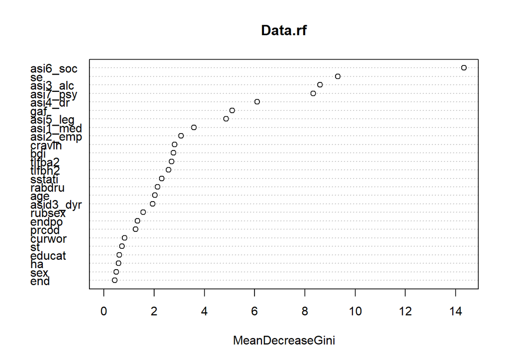

```r
varImpPlot(Data.rf)
```

## Проверка обученной модели на тестовых данных.

```r
Pred <- predict(Data.rf, newdata = DataTest)
table(Pred, DataTest$intpla)
```

```
##
## Pred  1  2
##    1 46  8
##    2  3 33
```

# Построим дерево классификаций:

```r
treeMy <- tree(intpla~ ., data = DataTrain)
summary(treeMy)
```

```
##
## Classification tree:
## tree(formula = intpla ~ ., data = DataTrain)
## Variables actually used in tree construction:
##  [1] "asi6_soc"  "asi4_dr"   "se"        "asid3_dyr" "asi1_med"
##  [6] "asi7_psy"  "asi3_alc"  "rabdru"    "tlfbh2"    "age"
## [11] "asi5_leg"  "tlfba2"
## Number of terminal nodes:  15
## Residual mean deviance:  0.2184 = 36.47 / 167
## Misclassification error rate: 0.05495 = 10 / 182
```

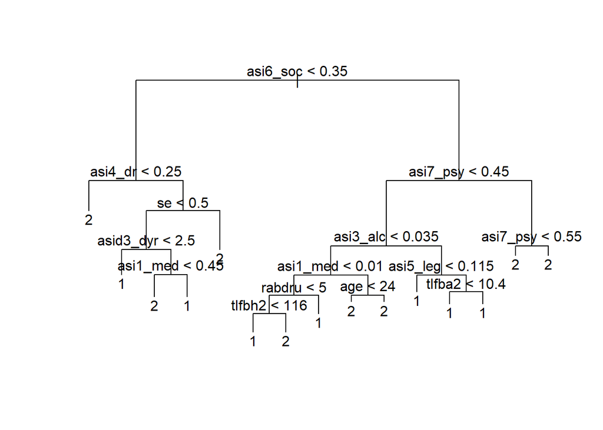

```r
plot(treeMy)
text(treeMy)
```

### Вопрос, а почему дерево такое? как оно рисуется? почему вот у se показатель именно 0.5? Это дерево вообщес строится по алгоритму CART (Classification And Regression Tree):

В алгоритме CART каждый узел дерева решений имеет двух потомков. На каждом шаге построения дерева правило, формируемое в узле, делит заданное множество примеров (обучающую выборку) на две части – часть, в которой выполняется правило (потомок – right) и часть, в которой правило не выполняется (потомок – left). Для выбора оптимального правила используется функция оценки качества разбиения.

Обучение дерева решений относится к классу обучения с учителем, то есть обучающая и тестовая выборки содержат классифицированный набор примеров. Оценочная функция, используемая алгоритмом CART, базируется на интуитивной идее уменьшения нечистоты (неопределённости) в узле.

В алгоритме CART идея ‘нечистоты’ формализована в индексе Gini (который оценивает “расстояние” между распределениями классов.). Если набор данных Т содержит данные n классов, тогда индекс Gini определяется как:

$Gini(T) = 1-\sum_{i=1}^np_i^2$, где $p_i$ — вероятность(относительная частота) класса i в T.

Если набор T разбивается на 2 части $T_1$ и $T_2$ с числом примеров в каждом $N_1$ и $N_2$ соответственно, тогда показатель качества разбиения будет равен:

$Gini_{split}(T)=\frac{N_1}{N}Gini(T_1)+\frac{N_2}{N}Gini(T_2)$

Наилучшим считается то разбиение, для которого $Gini_{split}(T)$ минимально.

Обозначим N – число примеров в узле – предке, L, R – число примеров соответственно в левом и правом потомке, $l_i$ и $r_i$ – число экземпляров i-го класса в левом/правом потомке. Тогда качество разбиения оценивается по следующей формуле:

$Gini_{split}=\frac{L}{N}(1-\sum_{i=1}^n(\frac{l_i}{L})^2)+\frac{R}{N}(1-\sum_{i=1}^n(\frac{r_i}{L})^2) -> min$

Чтобы уменьшить объем вычислений формулу можно преобразовать:

$Gini_{split}=\frac{1}{N}(L(1-\frac{1}{L^2}\sum_{i=1}^nl_i^2)+R(1-\frac{1}{R^2}\sum_{i=1}^nr_i^2)) -> min$

Так как умножение на константу не играет роли при минимизации:

$Gini_{split}=L -\frac{1}{L}\sum_{i=1}^nl_i^2+R-\frac{1}{R}\sum_{i=1}^nr_i^2 -> min$

$Gini_{split}=N -(\frac{1}{L}\sum_{i=1}^nl_i^2+\frac{1}{R}\sum_{i=1}^nr_i^2) -> min$

$\hat{G}_{split}=\frac{1}{L}\sum_{i=1}^nl_i^2+\frac{1}{R}\sum_{i=1}^nr_i^2 -> max$

В итоге, лучшим будет то разбиение, для которого величина $\hat{G}_{split}$ максимальна.

Если переменная числового типа, то в узле формируется правило вида $x_i <= c$. Где $с$ – некоторый порог, который чаще всего выбирается как среднее арифметическое двух соседних упорядоченных значений переменной $x_i$ обучающей выборки.

# Интересно, а как SVM справится с этими данными?

```r
model <- svm(intpla ~ ., data = DataTrain)
print(model)
```

```
##
## Call:
## svm(formula = intpla ~ ., data = DataTrain)
##
##
## Parameters:
##    SVM-Type:  C-classification
##  SVM-Kernel:  radial
##        cost:  1
##       gamma:  0.03846154
##
## Number of Support Vectors:  138
```

```r
summary(model)
```

```
##
## Call:
## svm(formula = intpla ~ ., data = DataTrain)
##
##
## Parameters:
##    SVM-Type:  C-classification
##  SVM-Kernel:  radial
##        cost:  1
##       gamma:  0.03846154
##
## Number of Support Vectors:  138
##
##  ( 71 67 )
##
##
## Number of Classes:  2
##
## Levels:
##  1 2
```

Проверим точность классификации:

```r
table(DataTrain$intpla == predict(model, subset(DataTrain), select = -intpla))
```

```
##
## FALSE  TRUE
##     4   178
```

На самом деле справилось немного лучше! Ведь впрошлом у нас было вот что:

```r
table(predict(Data.rf), DataTrain$intpla)
```

```
##
##      1  2
##   1 77  7
##   2 11 87
```

Проверим svm на тестовых данных:

```r
table(DataTest$intpla == predict(model, subset(DataTest), select = -intpla))
```

```
##
## FALSE  TRUE
##    16    74
```

Как то так, спасибо за внимание :)

# ВНИМАНИЕ

# Классификация в случае биномиальных распределений:

```r
Data <- read.csv("D:/Учеба/1 КУРС МАГИСТРАТУРА/Алексеева/DATA/DataNark.csv", header = TRUE, sep = ";",dec = ",")
```

Пусть у нас имеется p дихотомических признаков $X_1,..,X_p$, у нас p = 5, также у нас k=2: $W_1, W_2$:

```r
DataBinFull <- Data[,c("intpla", "sex","curwor","st", "ha", "se")]
head(DataBinFull)
```

```
##   intpla sex curwor st ha se
## 1      1   0      1  0  1  0
## 2      2   1      1  0  0  0
## 3      1   0      0  0  0  0
## 4      1   0      1  0  1  0
## 5      2   0      0  0  0  0
## 6      1   0      0  0  0  0
```

Разделим выборку на тестовую и обучающую:

```r
#сделаем рандомно это, перемешиваем индексы:
n <- nrow(DataBinFull)
index <- sample(n)
#т.е. 272/3=90,...   возьмем первые 90 для теста, остальные для обучения

DataBinRand <- DataBinFull[index,]
DataBinTest <- DataBinRand[1:90,]
DataBinTrain <- DataBinRand[(90+1):nrow(DataBinFull),]
```

Положим $P(X_j=1|W_i)=p_{ij}$ и $P(X_j=0|W_i)=1-p_{ij}$. Посчитаем эту матрицу $p_{ij}$:

для подсчета вероятности для начала изобрету велосипед (наверное), (не бейте):

```r
Data1 <- DataBinTrain[DataBinTrain[,1]=="1",] # чисто табличка для класса 1 (амбулаторно)
Data2 <- DataBinTrain[DataBinTrain[,1]=="2",] # чисто табличка для класса 2 (диспансер)
head(Data1)
```

```
##     intpla sex curwor st ha se
## 37       1   1      1  0  0  0
## 41       1   0      0  0  0  0
## 72       1   0      0  0  0  0
## 173      1   0      0  0  0  0
## 227      1   0      0  0  0  1
## 28       1   0      0  0  0  0
```

```r
head(Data2)
```

```
##     intpla sex curwor st ha se
## 248      2   1      0  0  0  1
## 101      2   0      0  0  0  0
## 218      2   0      0  0  0  1
## 232      2   1      0  0  0  1
## 55       2   1      0  0  0  0
## 70       2   1      0  0  1  0
```

### Считаем оценки $p_{ij}=\frac{n_{ij}}{n_i}$

```r
p <- matrix(5, nrow = 2, ncol = 5)
  for(j in (1:5)){
    p[1,j] <- nrow(Data1[Data1[,j+1]=="1",])/nrow(Data1)
    p[2,j] <- nrow(Data2[Data2[,j+1]=="1",])/nrow(Data2)
  }

p
```

```
##           [,1]      [,2]       [,3]      [,4]       [,5]
## [1,] 0.2298851 0.3908046 0.02298851 0.1494253 0.02298851
## [2,] 0.3578947 0.1684211 0.15789474 0.3157895 0.47368421
```

(хотя вроде нормально получилось)

### Итак, теперь считаем $q_i=n_i/n$: (это оценки априорных вероятностей)

```r
q1 <- nrow(Data1)/nrow(DataBinTrain)
q2 <- nrow(Data2)/nrow(DataBinTrain)
q1
```

```
## [1] 0.478022
```

```r
q2
```

```
## [1] 0.521978
```

## Давайте ка напишем функцию, которая будет проводить классификацию:

```r
KlassBin <- function(DataFun){ #Напишем для начала просто функцию, которую потом запусим!

f1 <- 1 #потому что умножаем
f2 <- 1
# f1 и f2 - это вероятности появления определенного вектора X, при условии W1 и W2 соответственно

m <- matrix(0, nrow = 2, ncol = 2) # Завели еще сразу матрицу 2*2 в которую будем заносить потихоньку результаты

for (i in (1:nrow(DataFun))){

  # Тут считаем f1(X) и f2(x):
  for (j in (1:5)){
    if (DataFun[i,j+1] == "1"){
      f1 <- f1*p[1,j]
      f2 <- f2*p[2,j]
    }
    if (DataFun[i,j+1] == "0"){
      f1 <- f1*(1-p[1,j])
      f2 <- f2*(1-p[2,j])
    }
  }

  # Посчитаем теперь P(X) - вероятность получения вектора X:

  P_X <- q1*f1+q2*f2

  # Посчитаем апостериорные вероятности P(W1|X) и P(W2|X):

  P_W1_X <- (q1*f1)/P_X
  P_W2_X <- (q2*f2)/P_X



  # Смотрим, куда отнести эту штуку (как классифицировать):

  if(P_W1_X>P_W2_X){
    # В этом условии мы классифицируем это как класс W1
    # И сейчас хотим занести в матрицу m результат, правильно или нет классифицировали:
    # т.е. мы сравниваем с правильным ответом:
    if(DataFun[i,1] == "1"){  # Было из класса W1 и классифицировали так же!
      m[1,1] <- m[1,1]+1
    }
    if(DataFun[i,1] == "2"){ # Было из класса W2, но классифицировали как W1!
      m[2,1] <- m[2,1]+1
    }
  }
    else{
    # В этом условии мы классифицируем это как класс W2
    # И сейчас хотим занести в матрицу m результат, правильно или нет классифицировали:
    # т.е. мы сравниваем с правильным ответом:
    if(DataFun[i,1] == "2"){  # Было из класса W2 и классифицировали так же!
      m[2,2] <- m[2,2]+1
    }
    if(DataFun[i,1] == "2"){ # Было из класса W1, но классифицировали как W2!
      m[1,2] <- m[1,2]+1
    }
  }
}

# ну вот а тут просто на вывод функции будет матрица m

 return(m)

}
```

## Ну давайте запустим это на обучающей выборке:

```r
KlassBin(DataBinTrain)
```

```
##      [,1] [,2]
## [1,]    3   95
## [2,]    0   95
```

Ну вот так вот плохо с этим справляется такая классификация….

Давайте еще все же глянем на тестовые данные:

```r
KlassBin(DataBinTest)
```

```
##      [,1] [,2]
## [1,]    6   37
## [2,]    3   37
```

Внимание, Вопроооос, а как же SVM ???

```r
model <- svm(intpla ~ ., data = DataBinTrain)
table(DataBinTrain$intpla == predict(model, subset(DataBinTrain), select = -intpla))
```

```
##
## FALSE  TRUE
##    47   135
```

Ну вот SVM справился горааааздо лучше!

SVM:

```r
table(DataBinTest$intpla == predict(model, subset(DataBinTest), select = -intpla))
```

```
##
## FALSE  TRUE
##    25    65
```

Ну тоже гораздо лучше!